# Pertemuan 6-7

Kezia Imanuella Victoria

# Packages

```r
library(ggplot2)
library(tsibble)
library(tseries)
library(MASS)
library(forecast)
library(TSA)
library(TTR)
library(aTSA)
library(graphics)
```

# Data

```r
library(readxl)
datasuhu <- read_excel("C:/Users/lenovo/Downloads/Data Pertemuan 6-7.xlsx")
datasuhu$Tanggal <- as.Date(datasuhu$Tanggal)
datasuhu.ts <- ts(datasuhu$Suhu_Max, frequency = 12)
datasuhu.ts<-ts(datasuhu)
```

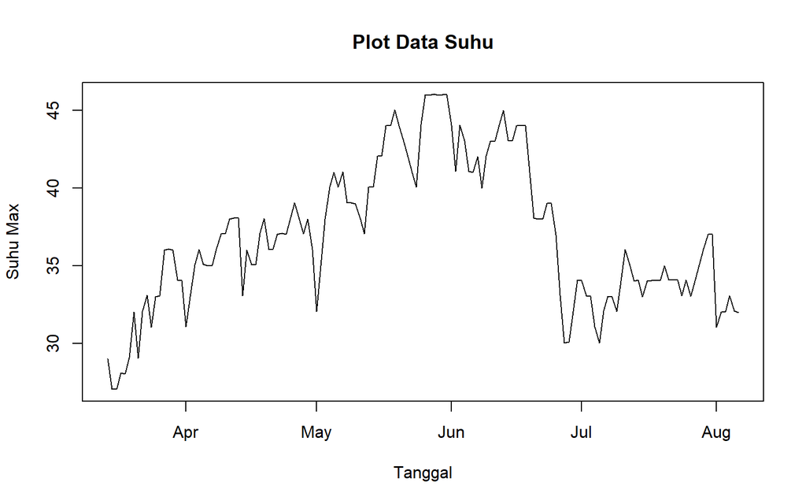

```r
plot(datasuhu$Tanggal, datasuhu$Suhu_Max, type = "l",
     xlab = "Tanggal", ylab = "Suhu Max", main = "Plot Data Suhu")
```

## Plot Data Latih

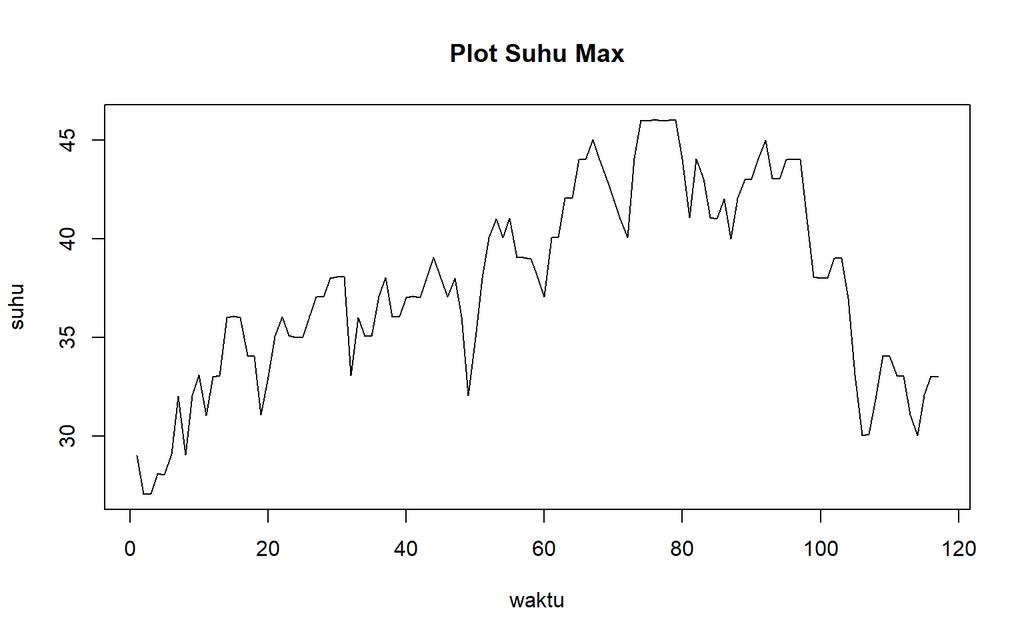

```r
suhutrain <- datasuhu$Suhu_Max[1:117]
train.ts<-ts(suhutrain)
plot.ts(train.ts, lty=1, xlab="waktu", ylab="suhu", main="Plot Suhu Max")
```

## Plot Data Uji

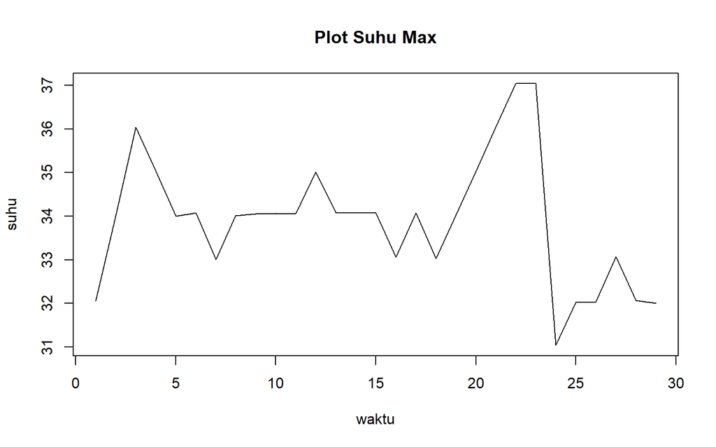

```r
suhutest <- datasuhu$Suhu_Max[118:146]
test.ts<-ts(suhutest)
plot.ts(test.ts, lty=1, xlab="waktu", ylab="suhu", main="Plot Suhu Max")
```

## Uji Stasioneritas Data

### Plot ACF

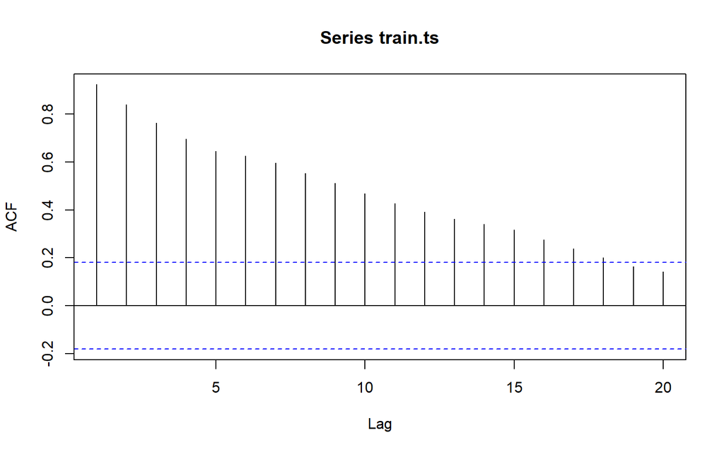

```r
acf(train.ts)
```

### Uji ADF

```r
tseries::adf.test(train.ts)
```

```
##
##  Augmented Dickey-Fuller Test
##
## data:  train.ts
## Dickey-Fuller = -1.2735, Lag order = 4, p-value = 0.8782
## alternative hypothesis: stationary
```

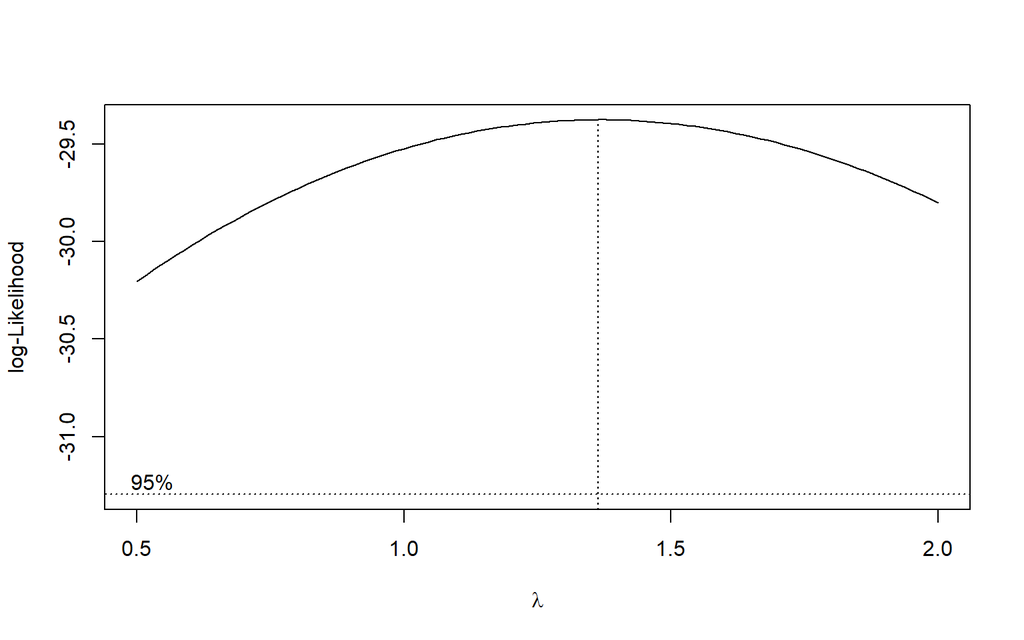

```r
index <- seq(1:117)

# Box-Cox
bc <- boxcox(train.ts ~ index, lambda = seq(0.5, 2, by = 0.1))
```

```r
# Nilai lambda optimum (rounded)
lambda_opt <- bc$x[which.max(bc$y)]
lambda_opt
```

```
## [1] 1.363636
```

```r
ci_lambda <- bc$x[bc$y > max(bc$y) - 0.5 * qchisq(0.95, df = 1)]

# Batas bawah dan batas atas
ci_lower <- min(ci_lambda)
ci_upper <- max(ci_lambda)

c(Batas_Bawah = ci_lower, Batas_Atas = ci_upper)
```

```
## Batas_Bawah  Batas_Atas
##         0.5         2.0
```

## Penanganan Ketidakstasioneran Data

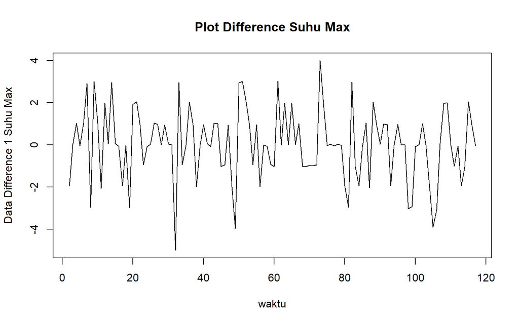

```r
# Dufferencing pertama
train.diff<-diff(train.ts,differences = 1)

# Plot hasil differencing
plot.ts(train.diff, lty=1, xlab="waktu", ylab="Data Difference 1 Suhu Max", main="Plot Difference Suhu Max")
```

Berdasarkan plot data deret waktu, terlihat bahwa data sudah cukup stasioner dalam rataan ditandai dengan data bergerak pada nilai tengah tertentu (tidak terdapat trend ataupun musiman pada data)

### Plot ACF

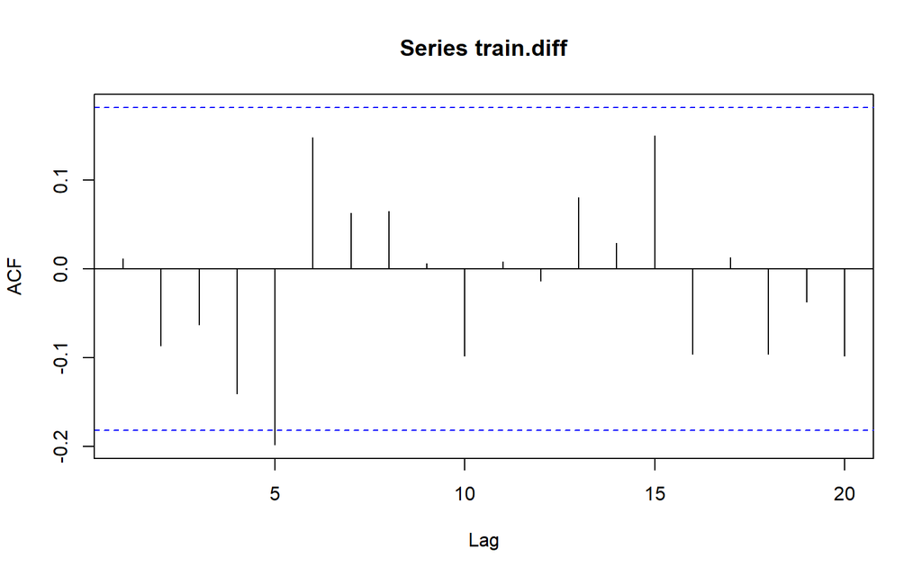

```r
acf(train.diff)
```

```r
tseries::adf.test(train.diff)
```

```
##
##  Augmented Dickey-Fuller Test
##
## data:  train.diff
## Dickey-Fuller = -7.4482, Lag order = 4, p-value = 0.01
## alternative hypothesis: stationary
```

Berdasarkan uji ADF tersebut, didapat p-value sebesar 0.01 yang lebih kecil dari taraf nyata 5% sehingga tolak atau data stasioner dalam rataan.

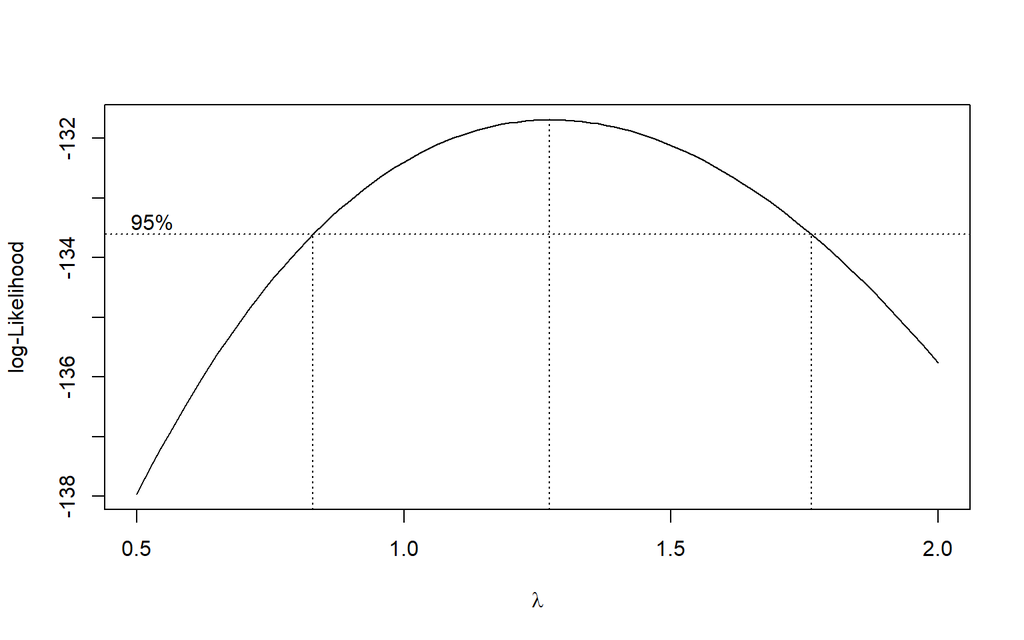

```r
library(MASS)

# Panjang index karena differencing menghilangkan 1 observasi awal
index_diff <- seq(1:length(train.diff))

min_val <- min(train.diff)

if (min_val <= 0) {
  c <- abs(min_val) + 1
  train.diff_shifted <- train.diff + c
} else {
  train.diff_shifted <- train.diff
}

# Plot Box-Cox pada data yang sudah di-shift
bc_diff <- boxcox(train.diff_shifted ~ index_diff, lambda = seq(0.5, 2, by = 0.1))
```

```r
# Nilai lambda optimum (rounded)
lambda_opt_diff <- bc_diff$x[which.max(bc_diff$y)]
print(paste("Lambda optimum setelah diff:", lambda_opt_diff))
```

```
## [1] "Lambda optimum setelah diff: 1.27272727272727"
```

```r
# Selang kepercayaan 95% untuk lambda
ci_lambda_diff <- bc_diff$x[bc_diff$y > max(bc_diff$y) - 0.5 * qchisq(0.95, df = 1)]

# Batas bawah dan batas atas
ci_lower_diff <- min(ci_lambda_diff)
ci_upper_diff <- max(ci_lambda_diff)

c(Batas_Bawah = ci_lower_diff, Batas_Atas = ci_upper_diff)
```

```
## Batas_Bawah  Batas_Atas
##   0.8333333   1.7575758
```

## Identifikasi Model

### Plot ACF

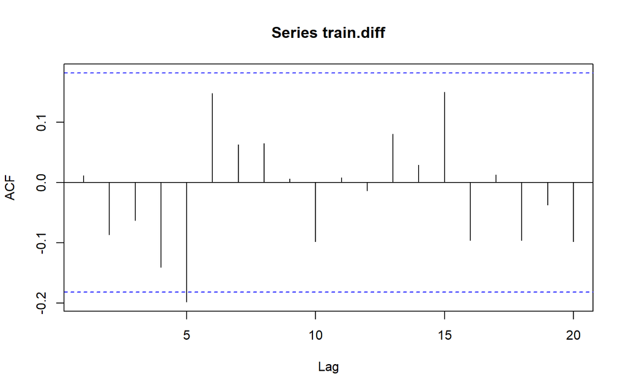

```r
acf(train.diff)
```

### Plot PACF

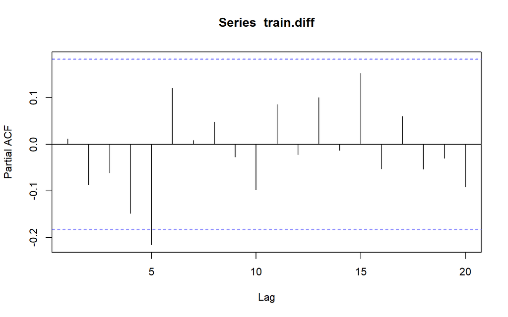

```r
pacf(train.diff)
```

Pada plot ACF dan PACF, tampak ada lag ke-5 yang melewati batas signifikansi bawah (sekitar -0.22). Namun, lag-lag awal (1 sampai 4) hampir semuanya berada di dalam batas atau membentuk pola cutoff. Ini mengindikasikan kemungkinan nilai $p$ kecil (seperti $p = 0$ atau $p = 1$).

```r
eacf(train.diff)
```

```
## AR/MA
##   0 1 2 3 4 5 6 7 8 9 10 11 12 13
## 0 o o o o x o o o o o o  o  o  o
## 1 o o o o o o o o o o o  o  o  o
## 2 x x o o x o o o o o o  o  o  o
## 3 x x o o x o o o o o o  o  o  o
## 4 x o o x x o o o o o o  o  o  o
## 5 x x x o x o o o o o o  o  o  o
## 6 o o o o o o o o o o o  o  o  o
## 7 x x o o o o o o o o o  o  o  o
```

Jika kita lihat pola sudut/segitiga “o” yang bersih di pojok kiri atas:  
-Baris 0, kolom 0, 1, 2, 3 berisi “o” $\rightarrow$ Kandidat: AR(0), MA(3) $\rightarrow$ ARIMA(0,1,3).  
-Atau jika ditarik ke bawah pada kolom 0: baris 0, 1 berisi “o” $\rightarrow$ Kandidat: AR(1), MA(0) $\rightarrow$ ARIMA(1,1,0).

## Pendugaan Parameter Model Tentatif

### ARIMA(0,1,1)

```r
model1.da=Arima(train.diff, order=c(0,0,1),method="ML")
summary(model1.da)
```

```
## Series: train.diff
## ARIMA(0,0,1) with non-zero mean
##
## Coefficients:
##          ma1    mean
##       0.0139  0.0342
## s.e.  0.1020  0.1583
##
## sigma^2 = 2.877:  log likelihood = -224.88
## AIC=455.76   AICc=455.98   BIC=464.03
##
## Training set error measures:
##                        ME     RMSE      MAE  MPE MAPE      MASE         ACF1
## Training set 0.0002381033 1.681526 1.245535 -Inf  Inf 0.7046266 -0.001227951
```

```r
lmtest::coeftest(model1.da)
```

```
##
## z test of coefficients:
##
##           Estimate Std. Error z value Pr(>|z|)
## ma1       0.013918   0.101991  0.1365   0.8915
## intercept 0.034233   0.158291  0.2163   0.8288
```

### ARIMA(1,1,0)

```r
model2.da=Arima(train.diff, order=c(1,0,0),method="ML")
summary(model2.da)
```

```
## Series: train.diff
## ARIMA(1,0,0) with non-zero mean
##
## Coefficients:
##          ar1    mean
##       0.0115  0.0343
## s.e.  0.0930  0.1579
##
## sigma^2 = 2.877:  log likelihood = -224.88
## AIC=455.77   AICc=455.98   BIC=464.03
##
## Training set error measures:
##                        ME     RMSE      MAE  MPE MAPE      MASE        ACF1
## Training set 0.0001994868 1.681549 1.245476 -Inf  Inf 0.7045931 0.000956316
```

```r
lmtest::coeftest(model2.da)
```

```
##
## z test of coefficients:
##
##           Estimate Std. Error z value Pr(>|z|)
## ar1       0.011540   0.093010  0.1241   0.9013
## intercept 0.034275   0.157944  0.2170   0.8282
```

### ARIMA(0,1,3)

```r
model3.da=Arima(train.diff, order=c(0,1,3),method="ML")
summary(model3.da)
```

```
## Series: train.diff
## ARIMA(0,1,3)
##
## Coefficients:
##           ma1      ma2     ma3
##       -0.9929  -0.1056  0.1166
## s.e.   0.1002   0.1213  0.1135
##
## sigma^2 = 2.933:  log likelihood = -225.27
## AIC=458.54   AICc=458.9   BIC=469.52
##
## Training set error measures:
##                      ME     RMSE      MAE  MPE MAPE      MASE       ACF1
## Training set -0.1132847 1.682814 1.289538 -Inf  Inf 0.7295202 0.01133218
```

```r
lmtest::coeftest(model3.da)
```

```
##
## z test of coefficients:
##
##     Estimate Std. Error z value Pr(>|z|)
## ma1 -0.99286    0.10023 -9.9057   <2e-16 ***
## ma2 -0.10558    0.12130 -0.8704   0.3841
## ma3  0.11663    0.11354  1.0272   0.3043
## ---
## Signif. codes:  0 '***' 0.001 '**' 0.01 '*' 0.05 '.' 0.1 ' ' 1
```

```r
model_tentatif <- data.frame(
  Model = c("ARIMA(0,1,1)","ARIMA(1,1,0)","ARIMA(0,1,3)"),
  AIC   = c(AIC(model1.da),AIC(model2.da), AIC(model3.da)),
  BIC   = c(BIC(model1.da),BIC(model2.da), BIC(model3.da))
)

model_tentatif
```

```
##          Model      AIC      BIC
## 1 ARIMA(0,1,1) 455.7647 464.0255
## 2 ARIMA(1,1,0) 455.7679 464.0287
## 3 ARIMA(0,1,3) 458.5353 469.5151
```

Berdasarkan pendugaan parameter di atas, nilai AIC terkecil dimiliki oleh model ARIMA(0,1,1)

## Analisis Sisaan

### Eksplorasi Sisaan

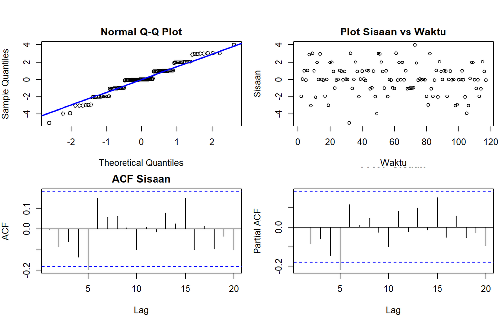

```r
sisaan.da <- model1.da$residuals

par(mfrow = c(2,2),
    mar = c(4,4,2,1),
    oma = c(0,0,2,0))

# Q-Q Plot
qqnorm(sisaan.da, main = "Normal Q-Q Plot")
qqline(sisaan.da, col = "blue", lwd = 2)

# Plot Sisaan vs Waktu
plot(sisaan.da, type = "p",
     main = "Plot Sisaan vs Waktu",
     xlab = "Waktu", ylab = "Sisaan")

# ACF
acf(sisaan.da, main = "ACF Sisaan")

# PACF
pacf(sisaan.da, main = "PACF Sisaan")
```

Berdasarkan plot kuantil-kuantil normal, secara eksploratif terlihat bahwa sisaan tidak sepenuhnya menyebar normal karena titik-titik cenderung menyimpang dari garis. Selain itu, lebar pita sebaran sisaan tampak tidak seragam, yang mengindikasikan adanya heterogenitas ragam.

```r
ks.test(sisaan.da,"pnorm")
```

```
##
##  Asymptotic one-sample Kolmogorov-Smirnov test
##
## data:  sisaan.da
## D = 0.18071, p-value = 0.001025
## alternative hypothesis: two-sided
```

Berdasarkan uji KS tersebut, didapat p-value sebesar 0.00 yang kurang dari taraf nyata 5% sehingga tolak H0 dan menandakan bahwa sisaan tidak menyebar normal. Hal ini sesuai dengan hasil eksplorasi menggunakan plot kuantil-kuantil normal.

```r
Box.test(sisaan.da, type = "Ljung")
```

```
##
##  Box-Ljung test
##
## data:  sisaan.da
## X-squared = 0.00017947, df = 1, p-value = 0.9893
```

Berdasarkan uji Ljung-Box tersebut, didapat p-value sebesar 0.9893 yang lebih besar dari taraf nyata 5% sehingga gagal tolak H0 dan menandakan bahwa sisaan saling bebas. Hal ini berbeda dengan eksplorasi.

```r
Box.test((sisaan.da)^2, type = "Ljung")
```

```
##
##  Box-Ljung test
##
## data:  (sisaan.da)^2
## X-squared = 6.4862, df = 1, p-value = 0.01087
```

Berdasarkan uji Ljung-Box terhadap sisaan kuadrat tersebut, didapat p-value sebesar 0.01087 yang kurang dari taraf nyata 5% sehingga tolak H0 dan menandakan bahwa ragam sisaan tidak homogen.

```r
t.test(sisaan.da, mu = 0, conf.level = 0.95)
```

```
##
##  One Sample t-test
##
## data:  sisaan.da
## t = 0.0015185, df = 115, p-value = 0.9988
## alternative hypothesis: true mean is not equal to 0
## 95 percent confidence interval:
##  -0.3103586  0.3108348
## sample estimates:
##    mean of x
## 0.0002381033
```

Berdasarkan uji-ttersebut, didapat p-value sebesar 0.9988 yang lebih besar dari taraf nyata 5% sehingga gagal tolak dan menandakan bahwa nilai tengah sisaan sama dengan nol.

## Overfitting

```r
model3.da=Arima(train.diff, order=c(0,0,2),method="ML")
summary(model3.da)
```

```
## Series: train.diff
## ARIMA(0,0,2) with non-zero mean
##
## Coefficients:
##           ma1      ma2    mean
##       -0.0109  -0.1160  0.0355
## s.e.   0.0974   0.1059  0.1359
##
## sigma^2 = 2.873:  log likelihood = -224.3
## AIC=456.61   AICc=456.97   BIC=467.62
##
## Training set error measures:
##                        ME     RMSE      MAE MPE MAPE      MASE      ACF1
## Training set -0.002134489 1.672976 1.260554 NaN  Inf 0.7131235 0.0127574
```

```r
lmtest::coeftest(model3.da)
```

```
##
## z test of coefficients:
##
##            Estimate Std. Error z value Pr(>|z|)
## ma1       -0.010944   0.097366 -0.1124   0.9105
## ma2       -0.116035   0.105925 -1.0954   0.2733
## intercept  0.035524   0.135942  0.2613   0.7938
```

## Model Terbaik : ARIMA(0,1,1)

```r
model1.da=Arima(train.diff, order=c(0,0,1),method="ML")
summary(model1.da)
```

```
## Series: train.diff
## ARIMA(0,0,1) with non-zero mean
##
## Coefficients:
##          ma1    mean
##       0.0139  0.0342
## s.e.  0.1020  0.1583
##
## sigma^2 = 2.877:  log likelihood = -224.88
## AIC=455.76   AICc=455.98   BIC=464.03
##
## Training set error measures:
##                        ME     RMSE      MAE  MPE MAPE      MASE         ACF1
## Training set 0.0002381033 1.681526 1.245535 -Inf  Inf 0.7046266 -0.001227951
```

```r
lmtest::coeftest(model1.da)
```

```
##
## z test of coefficients:
##
##           Estimate Std. Error z value Pr(>|z|)
## ma1       0.013918   0.101991  0.1365   0.8915
## intercept 0.034233   0.158291  0.2163   0.8288
```

## Peramalan

```r
# FORECAST
ramalan.da <- forecast::forecast(model1.da, h = length(test.ts))
```

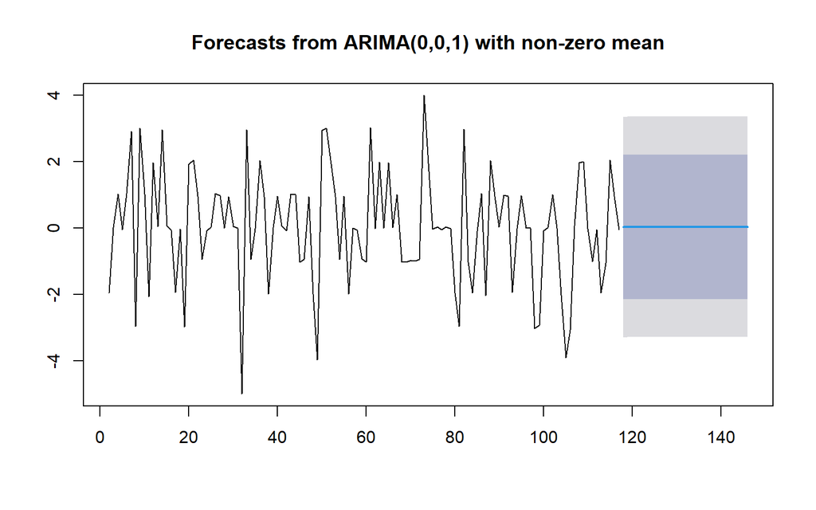

```r
data.ramalan.da <- ramalan.da$mean
plot(ramalan.da)
```

```r
pt_akhir_train <- tail(train.ts, 1)

forecast_inv <- diffinv(data.ramalan.da, differences = 1, xi = pt_akhir_train)
hasil <- forecast_inv[-1]
hasil <- hasil[1:length(test.ts)]

perbandingan.da <- cbind(
  Aktual   = test.ts,
  Forecast = hasil
)

print(head(perbandingan.da, 10))
```

```
## Time Series:
## Start = 1
## End = 10
## Frequency = 1
##    Aktual Forecast
##  1  32.06 33.03302
##  2  34.01 33.06726
##  3  36.04 33.10149
##  4  35.04 33.13572
##  5  34.00 33.16995
##  6  34.08 33.20419
##  7  33.01 33.23842
##  8  34.01 33.27265
##  9  34.05 33.30688
## 10  34.06 33.34112
```

```r
# Hitung akurasi
akurasi_test <- accuracy(hasil, test.ts)
akurasi_test
```

```
##                 ME     RMSE      MAE       MPE     MAPE      ACF1 Theil's U
## Test set 0.3928929 1.594575 1.322455 0.9688523 3.875617 0.5107978  1.126576
```

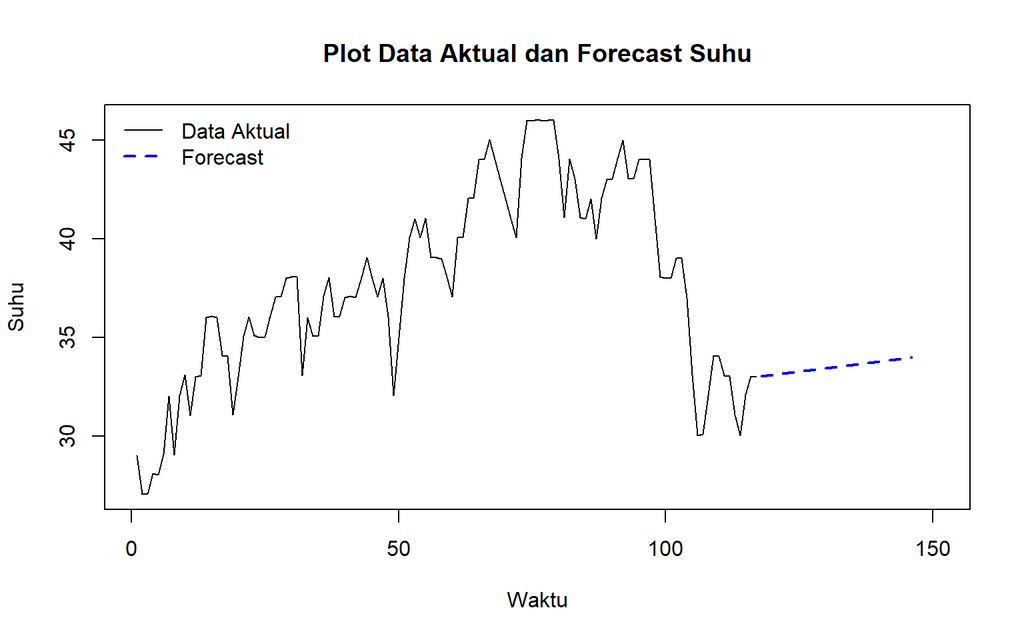

```r
ts.plot(train.ts, col = "black", lty = 1,
        xlab = "Waktu", ylab = "Suhu",
        main = "Plot Data Aktual dan Forecast Suhu",
        xlim = c(1, length(train.ts) + length(hasil) + 5)) # Memperlebar sumbu X agar ruang forecast terlihat

awal_x <- length(train.ts) + 1
akhir_x <- length(train.ts) + length(hasil)

lines(awal_x:akhir_x, hasil, col = "blue", lty = 2, lwd = 2)

legend("topleft",
       legend = c("Data Aktual", "Forecast"),
       col = c("black", "blue"),
       lty = c(1, 2), lwd = c(1, 2), bty = "n")
```